# Labs 8 & 9: Spiral Days

CMSC471: Introduction to Information Visualization (Spring 2026)

**Note**: These two labs and due **next Thu** (April 9, 2026 by 6pm). You submit **both labs in one checkout**, and you don’t have to submit anything for the week of March 30, 2026.

**Ever felt like traditional line charts don’t quite capture the rhythm of time**? Let’s break free from the straight-and-narrow and dive into **spiral visualizations**, a creative way to uncover repeated patterns in time-series data.

In this lab, we’ll build a **radial (spiral) time-based visualization** using **D3.js**, inspired by the redesign of COVID-19 case trends by **Wattenberger** ([see the right-hand example](https://x.com/abmakulec/status/1479496579040034822/photo/1)):

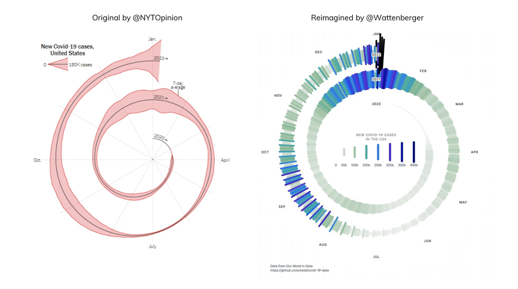

Twitter example

Instead of a conventional x-axis marching forward in time, our visualization **maps time along an outward-moving spiral**, emphasizing periodic patterns like **weekly, monthly, or yearly fluctuations**.

We’ll use **real-world COVID-19 case data** from Google’s [COVID-19 Open Data Repository](https://health.google.com/covid-19/open-data/raw-data). Specifically, we’ll focus on **U.S. daily confirmed cases** from `epidemiology.csv`. 👉 **[Download the dataset](https://fumeng-yang.github.io/CMSC471/handouts/COVID_US_cases.csv)**. The key columms are:

- **`date`** → When cases were reported (`YYYY-MM-DD` format).
- **`newConfirmed`** → Number of newly confirmed cases on that date.

We will pre-filled `NA` values with `0` for convenience. But in real-world analysis, different strategies exist—what are the trade-offs? Keep that in mind!

## Part 1: Setup

### Project structure

1. Locate your `CMSC471` folder.
2. Copy your any of your previous D3 labs into a new folder called `lab8-9/`.
3. Change the lab name in `index.html` to “Labs 8 & 9: Spiral Days”.
4. Add `COVID_US_cases.csv` to your `data/` folder. Your project should now look like this:

```
   lab8-9/
   ├── index.html
   ├── js/
   │   └── script.js
   ├── data/
   │   └── COVID_US_cases.csv
   └── css/
      └── styles.css
```

4. Start a local server:
   - VS Code extension “Live Server”: Click on `Go Live` and it should automatically open a browser for you
   - Python 3: `python -m http.server 8000`; visit: `http://localhost:8000`
5. Clean up your `index.html` and `script.js`.

   Your `index.html` should have only headers and `<svg id='vis'>`. Remove sliders and dropdown buttons.  
   Then, set up your `script.js` to create an `svg` canvas:

   ```javascript
   // your script.js
   const margin = { top: 40, right: 40, bottom: 40, left: 60 };
   const width = 700
   const height = 700

   const svg = d3.select('#vis')
      .append('svg')
      .attr('width', width)
      .attr('height', height)
      .append('g')
       // we use a square canvas
      .attr('transform', `translate(${width / 2},${height / 2})`);
   ```

Your browser should now display a blank SVG canvas like this:

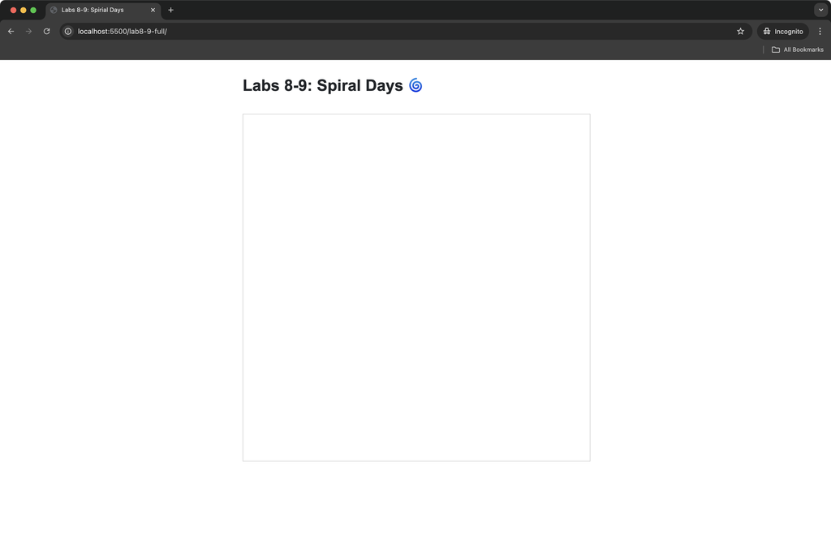

Setup of Labs 8-9

## Part 2: Code outline

First, let’s sketch out our code structure. Unlike our previous interactive visualizations, this one is (mostly) static, meaning we’ll load the dataset, parse it, and convert it to the correct format.

### Load the dataset

```javascript
// Load the data
function init() {
    d3.csv("data/COVID_US_cases.csv", d => ({
        // JavaScript's Date object stores time in UTC internally.
        // We add a time zone offset to avoid potential issues.
        date: new Date(d.date + 'T12:00:00.000+08:00'),
        // Convert confirmed cases to numbers; assume 0 if missing (NA)
        newConfirmed: +d.new_confirmed > 0 ? +d.new_confirmed : 0
    })).then(data => {
        console.log(data); // Check if data loads correctly
    });
}

// Run `init()` when the page loads
window.addEventListener('load', init);
```

[figure not shown]

Load data

### Structure the code

We’ll follow a structure similar to Labs 4-5, but since this visualization is static, there’s no need for event listeners or UI updates. Instead, we pass the cleaned data to `createVis()`, where we generate the spiral chart.

```javascript
// The main function that builds the visualization
// We pass the dataset as a parameter
function createVis(data) {
    // Spiral magic happens here!
}

// Load and process data
function init() {
    d3.csv("data/COVID_US_cases.csv", d => ({
        date: new Date(d.date),
        newConfirmed: +d.new_confirmed > 0 ? +d.new_confirmed : 0
    })).then(data => {
        console.log(data); // Debugging check
        createVis(data);   // Call visualization function
    });
}

// Run `init()` when the page loads
window.addEventListener('load', init);
```

## Part 3: Code adaption

### Find a spiral example

Not sure how to draw a spiral? No problem! Instead of reinventing the wheel (or the spiral), let’s Google some example code and build upon it.

Use the keywords “Spiral D3” to search, and switch to the “Images”. A quick glance lets us judge which examples match what we need—before diving into the code.

Here’s what your search results might look like:

[figure not shown]

Search results

We check out Results 1 & 3 first—since they look close to what we need.

[figure not shown]

The code of result 1

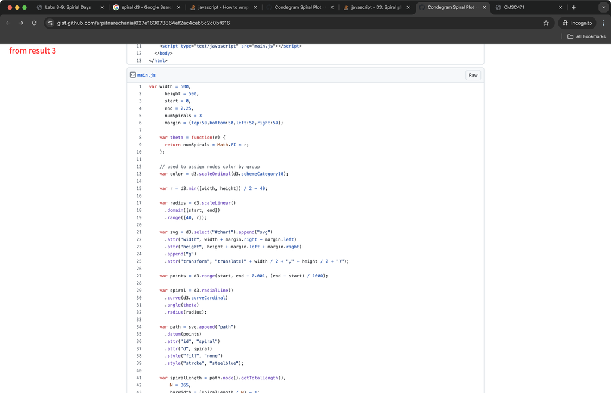

The code of result 3

Although these two examples seem good, after testing them, I found them difficult to modify. The parameter dependencies make it hard to control the spiral the way we need. Instead of struggling with multiple parameters, I found Result 2 to be short, clean, and easily adaptable:

[figure not shown]

The code of result 2

If you can’t find “Result 2” in your search results, you can download their code [here](https://fumeng-yang.github.io/CMSC471/handouts/lab8-9-starter.js).

### Reuse example code

Now let’s work on the example code.

#### Replicate the example

Before we make any changes, our first goal is simple: copy the code, run it in our setup, and make sure it works.  
We analyze Result 2 and extract the key functions:

[figure not shown]

A brief analysis of result 2

Your `script.js` should look something like this (NB: no need to copy the two lines with svg and g because we have similar code):

```javascript
const spiralArc = (fromRadius, toRadius, width, fromAngle, toAngle) => {
   ...
}

function createVis(data) {
    const WIDTH = 10;
    const BASE_RADIUS = 30;
    const angle = Math.PI * 2 / 30;
    ...
    for ...
       for ...
}
```

After saving the copied code, we get this result in our browser:

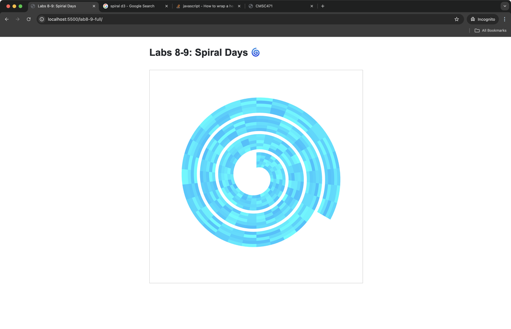

Replicate result 2

Success! Now let’s make it work for our dataset.

#### Modify the example

**1. Remove unnecessary “levels”**

The example was designed with five levels of arcs. We don’t need that—just keep one level (level = 0).

[figure not shown]

Remove levels

This simplifies our visualization:

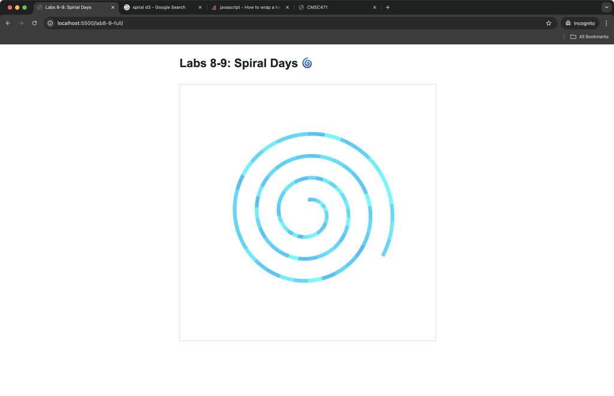

Remove levels

**2. Adjust the data length**

Right now, there are only ~30 sectors per year (one lap should be a year)—but we have 365 daily data points. We need to: Use one sector per day and set the angle increment to 2π / 365.

[figure not shown]

Change data length

After making this change, the spiral… looks weird. But don’t worry—we’ll fix it!

[figure not shown]

After changing data length

**3. Fix the spiral distortion**

The first thing to know is that this example is based on `arc` (each sector is an arc) with five parameters, `fromRadius`, `toRadius`, `fromAngle` (where the sector starts on the circle), `toAngle` (where the sector ends on the circle) and `width` (roughly means the width/height of a sector besides the spiral distortation).

The example code calculates `fromRadius` and `toRadius` based only on the `index`, but we need to account for the accumulated distortion as the spiral grows.

Currently, the offset grows linearly, which doesn’t correctly adjust for the spiral expansion. Instead, we’ll scale the index to better control the spacing.

So we try to adjust a scaling factor to `index` to control the size. Also, because the sectors are very small and we don’t need to be very precise, we can use the same `fromRadius` and `toRadius`. You can try different `fromRadius` and `toRadius` to see if your result is noticeably different.

[figure not shown]

Adjust radius

Using `OFFSET = .1` gives us this:

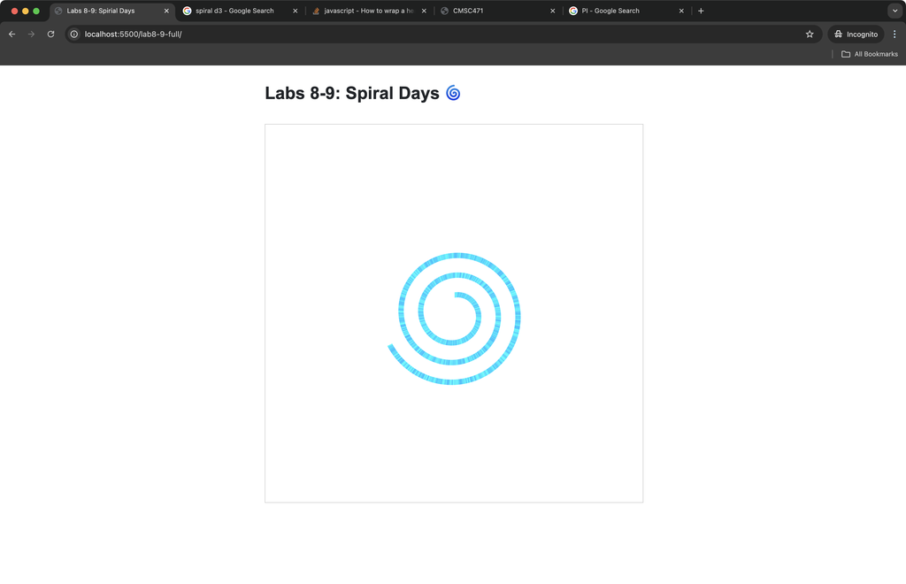

OFFSET = .1

We can make it bigger: `OFFSET = .25`

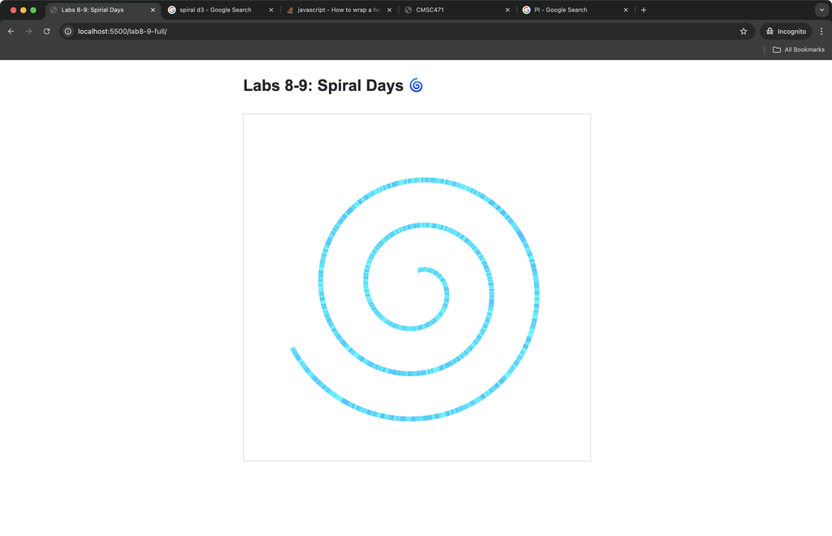

OFFSET = .25

**4. Map confirmed cases to sector height**

Right now, all arcs are the same height. But we want the height to reflect the number of confirmed cases per day. To do this: use a `scaleLinear()` function to map cases to `height`, and replace `WIDTH` with the scaled height.

[figure not shown]

Height scaling

Now, the visualization starts showing real trends!

[figure not shown]

Result after adding height

**5. Center-align the sectors**

Right now, the arcs start from a fixed base. To make them look more balanced, we offset the radius by half the height (`height / 2`) so the arcs grow outward evenly.

Here’s the cleaned-up and modified version of `createVis()`:

```javascript
function createVis(data) {
    const BASE_RADIUS = 30;
    const OFFSET = .25
    const angle = Math.PI * 2 / 365;

    let caseScale = d3.scaleLinear([1, d3.max(data.map(d => d.newConfirmed))], [1, 150])

    for (let index = 0; index < data.length; index++) {
        const height = caseScale(data[index].newConfirmed)
        const fromAngle = angle * index;
        const toAngle = angle * (index + 1);
        const fromRadius = toRadius = BASE_RADIUS +  OFFSET * index - height / 2;
        const path = spiralArc (fromRadius, toRadius, height, fromAngle, toAngle);
        const color = `rgb(0,${192 + Math.random() * 64},255)`
        svg.append('path')
            .attr('d', path)
            .style('fill', color)
    }
}
```

We have the basic visual encodings!

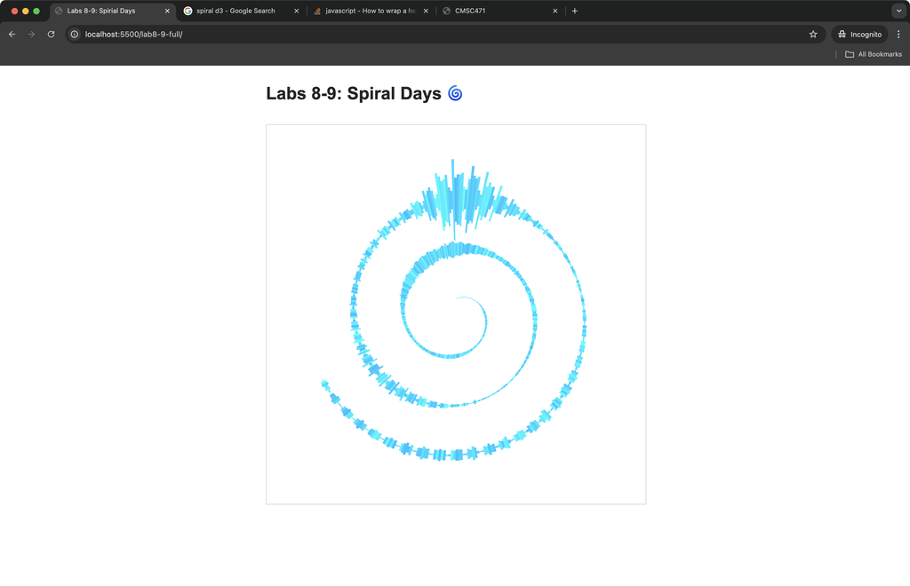

Result after offsetting by height

## Part 4: Colormap and label

### Define a color map

Right now, our colors are randomly generated. Let’s fix that by **mapping colors to case numbers** using a **custom colormap function**.

**Your task:**

- Choose a color map that makes sense for **COVID-19 case trends**.
- Replace the random color assignment (`rgb(0, 192 + Math.random() * 64, 255)`) with a **color-mapping function**.
- Add a **light stroke** to each path for better visibility.

**Option 1: D3’s built-in color scales**  
D3 provides some great color scales out of the box:

```javascript
let colorScale = d3.scaleSequential(d3.interpolateReds)
    .domain([0, d3.max(data.map(d => d.newConfirmed))]);
```

**Option 2: Custom hand-picked colors**  
If you want more control, define your own segmented color function like this:

```javascript
function colorScale(value) {
    if (value === 0) return "#E0E0E0";  // Light gray for zero cases
    if (value < 50) return "#FFC300";  // Yellow for low cases
    if (value < 200) return "#FF5733"; // Orange for moderate cases
    return "#C70039";  // Dark red for high cases
}
```

Thne you replace `const color = ...` with `const color = colorScale(data[index].newConfirmed)`

Here is what I use. Your may look different based on your chosen colormap:

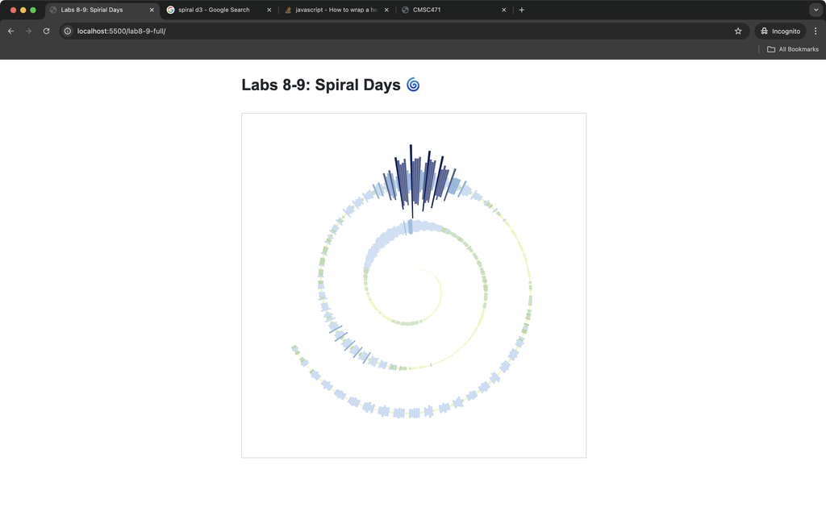

Use our colormap

### Add year labels

Now that we have our color map, let’s add year markers to make the visualization understandable.

Instead of binding text labels dynamically to data, we’ll directly place them within the for loop—since our spiral is positioned in the same loop.

Intuitively, we want to place a label for the start of each year.

First we need a function to extract year from a `Date` object. D3 provides a handy date formatting utility, `d3.timeFormat`, and you can view the documentation [here](https://d3js.org/d3-time-format).

```javascript
   const formatYear = d3.timeFormat("%Y")
```

This function returns a four-digit year (e.g., “2020”, “2021”).

**Inside our `for` loop**, we check if the current data point is the first day of the year (January 1st).

```javascript
   if (data[index].date.getDate() === 1 && data[index].date.getMonth() === 0) {
      let yearRadius = fromRadius
      let yearAngle = fromAngle
      svg.append('g')
         .attr("transform", `translate(${Math.sin(yearAngle) * yearRadius},
                             ${-Math.cos(yearAngle) * yearRadius})`)
         .append("text")
         .attr('dx', 0)
         .attr('dy', 0)
         .text(formatYear(data[index].date).toLowerCase())
         .attr("font-weight", 550)
         .attr("font-size", 10)
         .style('text-transform', 'small-caps')
         .style('fill', 'black')
         .style('text-anchor', 'middle')
         .attr('class', 'labels')
   }
```

To improve readability, we’ll add a subtle white outline (halo effect) to the text. Add the following code to `styles.css`:

```css
.labels {
    paint-order: stroke;
    stroke: #ffffffaa;
    stroke-width: 3px;
    stroke-linecap: round;
    stroke-linejoin: round;
}
```

Oops—our first label only shows 2021 and 2022!

[figure not shown]

After adding year labels

Why? The dataset starts on January 12, 2020, so we never capture “January 1, 2020”.

[figure not shown]

The first record in the dataset

To account for this, we:

- Start detecting years at “January 12” instead of “January 1”.
- Offset the label angle by 12 days for proper alignment.

```javascript
   if (data[index].date.getDate() === 12 && data[index].date.getMonth() === 0) {
      let yearRadius = fromRadius
      // Offset to align the first day in a month
      let yearAngle = fromAngle - angle * 12
      svg.append('g')
         .attr("transform", `translate(${Math.sin(yearAngle) * yearRadius},
                            ${-Math.cos(yearAngle) * yearRadius})`)
         .append("text")
         .attr('dx', 0)
         .attr('dy', 0)
         .text(formatYear(data[index].date).toLowerCase())
         .attr("font-weight", 550)
         .attr("font-size", 10)
         .style('text-transform', 'small-caps')
         .style('fill', 'black')
         .style('text-anchor', 'middle')
         .attr('class', 'labels')
   }
```

Now our year labels are correctly placed!

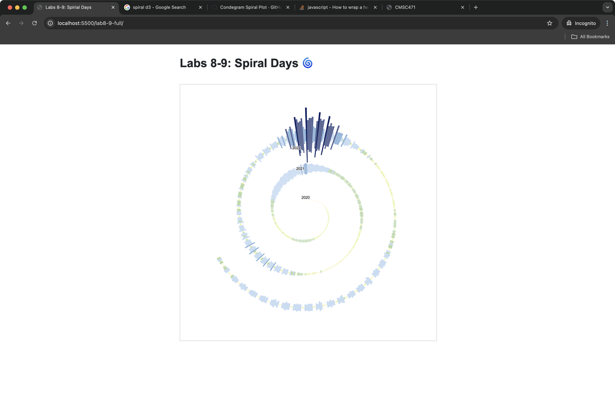

The year labels

### Add month labels

Now that our year labels are in place, let’s add month labels to improve readability.

Similar to how we extracted the year, we can use D3’s `timeFormat` function to get shortened month names (e.g., Jan, Feb, Mar, etc.):

```javascript
   const formatMonth = d3.timeFormat("%b")    // 'Jan', 'Feb', 'Mar', ...
```

**Inside our `for` loop**, we add code to check if the current date is the first day of the month and add a label at that position.

```javascript
if (data[index].date.getDate() === 1){
      let textRadius = fromRadius + 30 // A magic number - feel free to improve!
      svg.append('text')
         .attr("transform", `translate(${Math.sin(fromAngle) * textRadius},
            ${-Math.cos(fromAngle) * textRadius})`)
         .text(formatMonth(data[index].date).toLowerCase())
         .attr("font-weight", 550)
         .attr("font-size", 14)
         .style('font-variant', 'small-caps')
         .style('fill', 'black')
         .style('text-anchor', 'middle')
         .attr('class', 'labels')
}
```

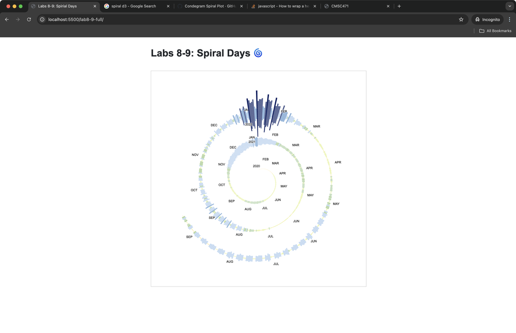

All month labels

Too many labels! Uh-oh—this adds labels for every month across all years, making the visualization too cluttered. So we need only the last lap, where we conditionally display Oct 2021 to Sep 2022.

**Your task**

We only want month labels for Oct 2021 to Sep 2022

- Use `getFullYear()` to get the year (e.g., 2021, 2022)
- Use `getMonth()` to get the month (0 = Jan, 11 = Dec)
- Conditionally display labels only for dates within Oct 2021 - Sep 2022. Modify the condition inside `if()` to only include months in this range.

Notice how the start of the year is slightly off-center? That’s because we shifted the year labels by 12 days. You can adjust `fromAngle` and `toAngle` to nudge the labels into better alignment. This improvement is optional.

Now we have a clear, uncluttered spiral with readable month labels:

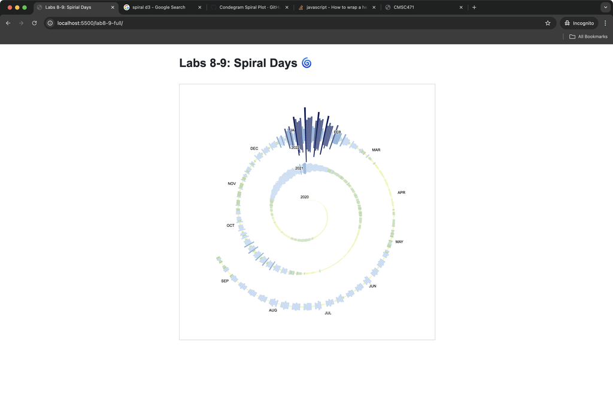

Clean labels

## Part 5: Final retouch

We’re almost there! Now let’s refine our visualization by adding:

- A meaningful title & subtitle
- A legend to explain the color encoding
- A paragraph for data interpretation
- (Optional) Tooltips for interactive exploration

### Title and subtitle

A well-designed visualization needs a clear title to explain what’s being shown. So we modify `createVis()` to add a title and subtitle. **Note that you should use title that reflect your visualization (e.g. colormap)**.

```javascript
    svg.append('text')
    .attr('x', 0)
    .attr('y', -height / 2 + margin.top)
    .text('new (old) covid-19 cases in the usa')
    .style('fill', '#555555')
    .style('font-size', 16)
    .style("font-weight", 600)
    .style('text-anchor', 'middle')
    .style('text-transform', 'uppercase')

    svg.append('text')
    .attr('x',   0)
    .attr('y',  -height / 2  + margin.top + 20)
    .text('color picked for aesthethics and might not be truthful')
    .style('fill', '#888888')
    .style('font-size', 12)
    .style('text-anchor', 'middle')
    .style("font-weight", 400)
```

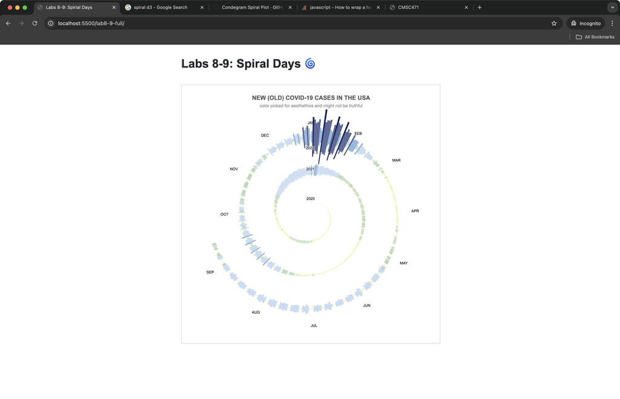

Add title

### Add a legend

A good legend helps users interpret what the **colors** and **heights** represent. **The design and placement of your legend are entirely up to you**. Usually you want to define the data (see an example below) and call your scale (`caseScale()`) and `colorScale` functions to draw these bars.

For example, you can define

```javascript
const legendData = [10000, 50000, 100000, 250000, 500000, 1000000, 1500000]
```

**Your task**

Add code in `createVis()` to:

- Draw legend bars with appropriate colors and labels
- Use `caseScale()` to determine bar heights
- Use the same `colorScale()` function as the main visualization
- Add `text` labels next to the bars

Here’s an example of what your legend might look like:

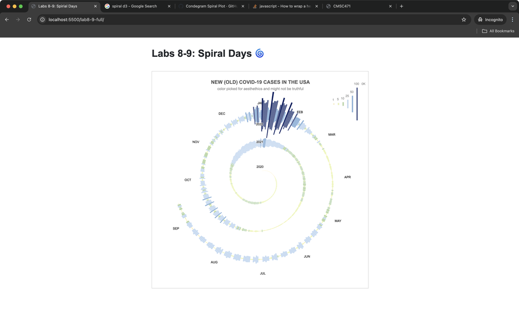

Add legend

### Add a paragraph explanation

A visualization without context can be misleading. Let’s add a brief description explaining:

- The data source
- Any color mapping decisions
- Observations or trends from the spiral

[figure not shown]

Add explanation

### Add tooltips (optional)

Finally you can copy code from your Lab 4-5 to add a tooltip. **Hint**: this should be added to `path` and change `d` to `data[index]`. Also, you may want to look at [`d3.timeFormat`](https://d3js.org/d3-time-format) documentation again to format dates.

[figure not shown]

Add tooltip

### AI usage

- **Permitted uses**: AI tools may be used for brainstorming, generating ideas, improving writing clarity, debugging code, and explaining concepts or code snippets.
- **Prohibited uses for labs**: Using AI tools to directly complete labs is strictly prohibited. If such use is identified, the corresponding lab will receive a 66% score reduction and no further submission for this lab will be accepted.
- **Conceptual understanding checks**: During lab checkouts, we will ask conceptual questions related to the lab to ensure understanding. Repeated inability to answer these questions will result in an additional 33% deduction.

## Checklist ✓

**Spiral visualization**: Each sector represents one record; radii and colormap may vary  
**Correct labels**: Year and month labels are accurately placed  
**Chosen colormap**: A well-defined color scale that maps values meaningfully  
**Titles & subtitles**: Clearly describe what the visualization represents  
**Legend**: Explains color encoding and case numbers but its position may vary  
**Data explanation**: A brief paragraph describing the data source and key insights  
**Tooltip** (optional but recommended): Allows interactive exploration of data

## Submission process

- Raise your hand ✋
- Show the working webpage
- Briefly explain your colormap and takeaways
- Show your project structure in VS code; let us skim your `script.js`
- Any additional features implemented
- Confirm your name

### Notes for TAs

- **Colormap Justification**: Students should provide a brief explanation of their colormap choice (why they used a specific color gradient and how it relates to the data).
- **Variability**: The visualization should readable, shows the trend, and uses a reasonable colormap, but size and colors may vary.
- **Label positioning**: Verify that **month labels** appear only on the final spiral loop (e.g., Oct 2021 – Sep 2022).
- **Data source citation**: Ensure students reference the dataset source in their explanation.
- **Tooltip (if implemented)**: Check that tooltips display meaningful information (e.g., date, new cases).

## Debugging tips

1. **Ensure proper dataset loading**
   - Check your browser console for error messages.
   - Verify that all data points have `date` and `newConfirmed` values parsed correctly.
2. **Check for incorrect scaling**
   - Print out scale mappings:

     ```javascript
     console.log('Scale test: ', caseScale(10000), caseScale(1000000));
     ```

   - Adjust scale ranges if bars are too small or too large.
3. **Ensure spiral layout is working**
   - Try setting `OFFSET = 0.1` and inspect the layout.
   - If sectors look misaligned, check if you need to adjust `fromRadius`, `toRadius`, or `angle`.
4. **Check color mappings**
   - Test color function:

     ```javascript
     console.log('Color test:', colormap(10000), colormap(1000000));
     ```

   - Ensure colors are distinguishable and reflect meaningful differences in data.
5. **Verify labels are placed correctly**
   - If labels are missing, check:

     ```javascript
     console.log(formatMonth(data[index].date), formatYear(data[index].date));
     ```

   - Use a fixed text offset (`dx, dy`) to avoid overlaps.